# Risk Factor Analysis

## Outcome Variable

**Outcome Variable:** sstunted

## Predictor Variables

**Intervention Variable:** brthmon

**Adjustment Set:**

unadjusted

## Stratifying Variables

The analysis was stratified on these variable(s):

- agecat
- studyid
- country

## Data Summary

| agecat | studyid | country | brthmon | sstunted | n_cell | n |
| --- | --- | --- | --- | --- | --- | --- |
| Birth | CMC-V-BCS-2002 | INDIA | 1 | 0 | 9 | 92 |
| Birth | CMC-V-BCS-2002 | INDIA | 1 | 1 | 0 | 92 |
| Birth | CMC-V-BCS-2002 | INDIA | 2 | 0 | 1 | 92 |
| Birth | CMC-V-BCS-2002 | INDIA | 2 | 1 | 0 | 92 |
| Birth | CMC-V-BCS-2002 | INDIA | 3 | 0 | 7 | 92 |
| Birth | CMC-V-BCS-2002 | INDIA | 3 | 1 | 1 | 92 |
| Birth | CMC-V-BCS-2002 | INDIA | 4 | 0 | 9 | 92 |
| Birth | CMC-V-BCS-2002 | INDIA | 4 | 1 | 0 | 92 |
| Birth | CMC-V-BCS-2002 | INDIA | 5 | 0 | 12 | 92 |
| Birth | CMC-V-BCS-2002 | INDIA | 5 | 1 | 0 | 92 |
| Birth | CMC-V-BCS-2002 | INDIA | 6 | 0 | 9 | 92 |
| Birth | CMC-V-BCS-2002 | INDIA | 6 | 1 | 0 | 92 |
| Birth | CMC-V-BCS-2002 | INDIA | 7 | 0 | 7 | 92 |
| Birth | CMC-V-BCS-2002 | INDIA | 7 | 1 | 0 | 92 |
| Birth | CMC-V-BCS-2002 | INDIA | 8 | 0 | 4 | 92 |
| Birth | CMC-V-BCS-2002 | INDIA | 8 | 1 | 0 | 92 |
| Birth | CMC-V-BCS-2002 | INDIA | 9 | 0 | 7 | 92 |
| Birth | CMC-V-BCS-2002 | INDIA | 9 | 1 | 1 | 92 |
| Birth | CMC-V-BCS-2002 | INDIA | 10 | 0 | 9 | 92 |
| Birth | CMC-V-BCS-2002 | INDIA | 10 | 1 | 1 | 92 |
| Birth | CMC-V-BCS-2002 | INDIA | 11 | 0 | 11 | 92 |
| Birth | CMC-V-BCS-2002 | INDIA | 11 | 1 | 0 | 92 |
| Birth | CMC-V-BCS-2002 | INDIA | 12 | 0 | 3 | 92 |
| Birth | CMC-V-BCS-2002 | INDIA | 12 | 1 | 1 | 92 |
| Birth | CMIN | BANGLADESH | 1 | 0 | 3 | 26 |
| Birth | CMIN | BANGLADESH | 1 | 1 | 2 | 26 |
| Birth | CMIN | BANGLADESH | 2 | 0 | 4 | 26 |
| Birth | CMIN | BANGLADESH | 2 | 1 | 0 | 26 |
| Birth | CMIN | BANGLADESH | 3 | 0 | 0 | 26 |
| Birth | CMIN | BANGLADESH | 3 | 1 | 0 | 26 |

[output cut: 1506 more lines]

The following strata were considered:

- agecat: 24 months, studyid: CMC-V-BCS-2002, country: INDIA
- agecat: 24 months, studyid: CMIN, country: BANGLADESH
- agecat: 24 months, studyid: CONTENT, country: PERU
- agecat: 24 months, studyid: EE, country: PAKISTAN
- agecat: 24 months, studyid: GMS-Nepal, country: NEPAL
- agecat: 24 months, studyid: IRC, country: INDIA
- agecat: 24 months, studyid: Keneba, country: GAMBIA
- agecat: 24 months, studyid: LCNI-5, country: MALAWI
- agecat: 24 months, studyid: MAL-ED, country: BANGLADESH
- agecat: 24 months, studyid: MAL-ED, country: BRAZIL
- agecat: 24 months, studyid: MAL-ED, country: INDIA
- agecat: 24 months, studyid: MAL-ED, country: NEPAL
- agecat: 24 months, studyid: MAL-ED, country: PERU
- agecat: 24 months, studyid: MAL-ED, country: SOUTH AFRICA
- agecat: 24 months, studyid: MAL-ED, country: TANZANIA, UNITED REPUBLIC OF
- agecat: 24 months, studyid: NIH-Birth, country: BANGLADESH
- agecat: 24 months, studyid: PROBIT, country: BELARUS
- agecat: 24 months, studyid: PROVIDE, country: BANGLADESH
- agecat: 24 months, studyid: TanzaniaChild2, country: TANZANIA, UNITED REPUBLIC OF
- agecat: 24 months, studyid: ZVITAMBO, country: ZIMBABWE
- agecat: 6 months, studyid: CMC-V-BCS-2002, country: INDIA
- agecat: 6 months, studyid: CMIN, country: BANGLADESH
- agecat: 6 months, studyid: CONTENT, country: PERU
- agecat: 6 months, studyid: EE, country: PAKISTAN
- agecat: 6 months, studyid: GMS-Nepal, country: NEPAL
- agecat: 6 months, studyid: Guatemala BSC, country: GUATEMALA
- agecat: 6 months, studyid: IRC, country: INDIA
- agecat: 6 months, studyid: Keneba, country: GAMBIA
- agecat: 6 months, studyid: LCNI-5, country: MALAWI
- agecat: 6 months, studyid: MAL-ED, country: BANGLADESH
- agecat: 6 months, studyid: MAL-ED, country: BRAZIL
- agecat: 6 months, studyid: MAL-ED, country: INDIA
- agecat: 6 months, studyid: MAL-ED, country: NEPAL
- agecat: 6 months, studyid: MAL-ED, country: PERU
- agecat: 6 months, studyid: MAL-ED, country: SOUTH AFRICA
- agecat: 6 months, studyid: MAL-ED, country: TANZANIA, UNITED REPUBLIC OF
- agecat: 6 months, studyid: NIH-Birth, country: BANGLADESH
- agecat: 6 months, studyid: PROBIT, country: BELARUS
- agecat: 6 months, studyid: PROVIDE, country: BANGLADESH
- agecat: 6 months, studyid: ResPak, country: PAKISTAN
- agecat: 6 months, studyid: SAS-CompFeed, country: INDIA
- agecat: 6 months, studyid: SAS-FoodSuppl, country: INDIA
- agecat: 6 months, studyid: TanzaniaChild2, country: TANZANIA, UNITED REPUBLIC OF
- agecat: 6 months, studyid: ZVITAMBO, country: ZIMBABWE
- agecat: Birth, studyid: CMC-V-BCS-2002, country: INDIA
- agecat: Birth, studyid: CMIN, country: BANGLADESH
- agecat: Birth, studyid: CONTENT, country: PERU
- agecat: Birth, studyid: EE, country: PAKISTAN
- agecat: Birth, studyid: GMS-Nepal, country: NEPAL
- agecat: Birth, studyid: IRC, country: INDIA
- agecat: Birth, studyid: Keneba, country: GAMBIA
- agecat: Birth, studyid: MAL-ED, country: BANGLADESH
- agecat: Birth, studyid: MAL-ED, country: BRAZIL
- agecat: Birth, studyid: MAL-ED, country: INDIA
- agecat: Birth, studyid: MAL-ED, country: NEPAL
- agecat: Birth, studyid: MAL-ED, country: PERU
- agecat: Birth, studyid: MAL-ED, country: SOUTH AFRICA
- agecat: Birth, studyid: MAL-ED, country: TANZANIA, UNITED REPUBLIC OF
- agecat: Birth, studyid: NIH-Birth, country: BANGLADESH
- agecat: Birth, studyid: PROBIT, country: BELARUS
- agecat: Birth, studyid: PROVIDE, country: BANGLADESH
- agecat: Birth, studyid: ResPak, country: PAKISTAN
- agecat: Birth, studyid: SAS-CompFeed, country: INDIA
- agecat: Birth, studyid: ZVITAMBO, country: ZIMBABWE

### Dropped Strata

Some strata were dropped due to rare outcomes:

- agecat: Birth, studyid: CMC-V-BCS-2002, country: INDIA
- agecat: Birth, studyid: CMIN, country: BANGLADESH
- agecat: Birth, studyid: CONTENT, country: PERU
- agecat: Birth, studyid: EE, country: PAKISTAN
- agecat: Birth, studyid: GMS-Nepal, country: NEPAL
- agecat: Birth, studyid: IRC, country: INDIA
- agecat: Birth, studyid: Keneba, country: GAMBIA
- agecat: Birth, studyid: MAL-ED, country: BANGLADESH
- agecat: Birth, studyid: MAL-ED, country: BRAZIL
- agecat: Birth, studyid: MAL-ED, country: INDIA
- agecat: Birth, studyid: MAL-ED, country: NEPAL
- agecat: Birth, studyid: MAL-ED, country: PERU
- agecat: Birth, studyid: MAL-ED, country: SOUTH AFRICA
- agecat: Birth, studyid: MAL-ED, country: TANZANIA, UNITED REPUBLIC OF
- agecat: Birth, studyid: NIH-Birth, country: BANGLADESH
- agecat: Birth, studyid: PROBIT, country: BELARUS
- agecat: Birth, studyid: PROVIDE, country: BANGLADESH
- agecat: Birth, studyid: ResPak, country: PAKISTAN
- agecat: Birth, studyid: SAS-CompFeed, country: INDIA
- agecat: 6 months, studyid: CMC-V-BCS-2002, country: INDIA
- agecat: 6 months, studyid: CMIN, country: BANGLADESH
- agecat: 6 months, studyid: CONTENT, country: PERU
- agecat: 6 months, studyid: EE, country: PAKISTAN
- agecat: 6 months, studyid: GMS-Nepal, country: NEPAL
- agecat: 6 months, studyid: Guatemala BSC, country: GUATEMALA
- agecat: 6 months, studyid: IRC, country: INDIA
- agecat: 6 months, studyid: Keneba, country: GAMBIA
- agecat: 6 months, studyid: LCNI-5, country: MALAWI
- agecat: 6 months, studyid: MAL-ED, country: BANGLADESH
- agecat: 6 months, studyid: MAL-ED, country: BRAZIL
- agecat: 6 months, studyid: MAL-ED, country: INDIA
- agecat: 6 months, studyid: MAL-ED, country: NEPAL
- agecat: 6 months, studyid: MAL-ED, country: PERU
- agecat: 6 months, studyid: MAL-ED, country: SOUTH AFRICA
- agecat: 6 months, studyid: MAL-ED, country: TANZANIA, UNITED REPUBLIC OF
- agecat: 6 months, studyid: NIH-Birth, country: BANGLADESH
- agecat: 6 months, studyid: PROVIDE, country: BANGLADESH
- agecat: 6 months, studyid: ResPak, country: PAKISTAN
- agecat: 6 months, studyid: SAS-CompFeed, country: INDIA
- agecat: 6 months, studyid: SAS-FoodSuppl, country: INDIA
- agecat: 6 months, studyid: TanzaniaChild2, country: TANZANIA, UNITED REPUBLIC OF
- agecat: 24 months, studyid: CMC-V-BCS-2002, country: INDIA
- agecat: 24 months, studyid: CMIN, country: BANGLADESH
- agecat: 24 months, studyid: CONTENT, country: PERU
- agecat: 24 months, studyid: EE, country: PAKISTAN
- agecat: 24 months, studyid: GMS-Nepal, country: NEPAL
- agecat: 24 months, studyid: IRC, country: INDIA
- agecat: 24 months, studyid: LCNI-5, country: MALAWI
- agecat: 24 months, studyid: MAL-ED, country: BANGLADESH
- agecat: 24 months, studyid: MAL-ED, country: BRAZIL
- agecat: 24 months, studyid: MAL-ED, country: INDIA
- agecat: 24 months, studyid: MAL-ED, country: NEPAL
- agecat: 24 months, studyid: MAL-ED, country: PERU
- agecat: 24 months, studyid: MAL-ED, country: SOUTH AFRICA
- agecat: 24 months, studyid: MAL-ED, country: TANZANIA, UNITED REPUBLIC OF
- agecat: 24 months, studyid: NIH-Birth, country: BANGLADESH
- agecat: 24 months, studyid: PROBIT, country: BELARUS
- agecat: 24 months, studyid: PROVIDE, country: BANGLADESH
- agecat: 24 months, studyid: TanzaniaChild2, country: TANZANIA, UNITED REPUBLIC OF
- agecat: 24 months, studyid: ZVITAMBO, country: ZIMBABWE

## Methods Detail

We’re interested in the causal parameters $E[Y_a]$ for all values of $a \in \mathcal{A}$. These parameters represent the mean outcome if, possibly contrary to fact, we intervened to set all units to have $A=a$. Under the randomization and positivity assumptions, these are identified by the statistical parameters $\psi_a=E_W[E_{Y|A,W}(Y|A=a,W)]$. In addition, we’re interested in the mean of $Y$, $E[Y]$ under no intervention (the observed mean). We will estimate these parameters by using SuperLearner to fit the relevant likelihood factors – $E_{Y|A,W}(Y|A=a,W)$ and $p(A=a|W)$, and then updating our likelihood fit using a joint TMLE.

For unadjusted analyses ($W=\{\}$), initial likelihoods were estimated using Lrnr_glm to estimate the simple $E(Y|A)$ and Lrnr_mean to estimate $p(A)$. For adjusted analyses, a small library containing Lrnr_glmnet, Lrnr_xgboost, and Lrnr_mean was used.

Having estimated these parameters, we will then use the delta method to estimate relative risks and attributable risks relative to a prespecified baseline level of $A$.

# Results Detail

## Results Plots

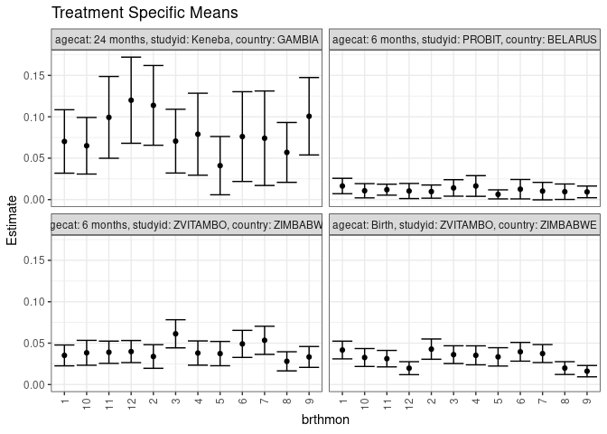

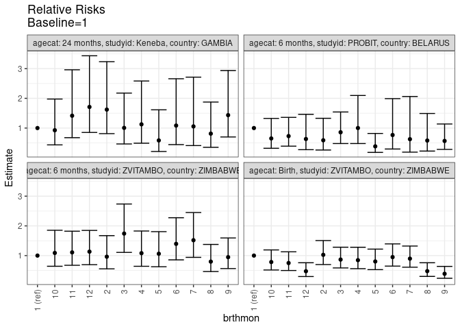

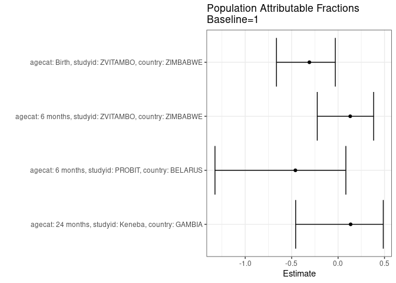

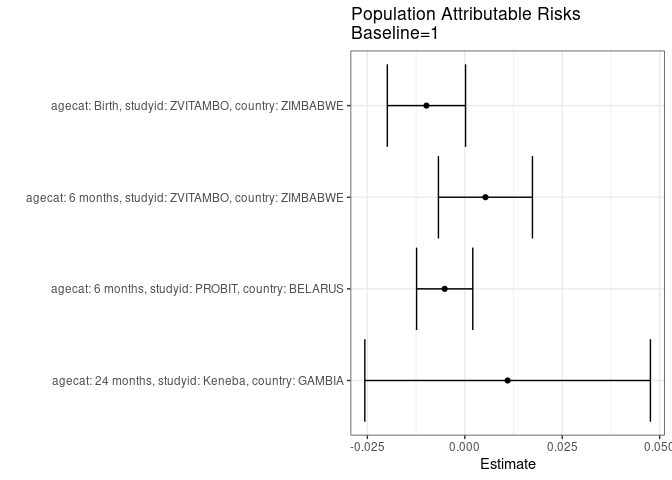

## Results Table

### Parameter: TSM

| agecat | studyid | country | intervention_level | baseline_level | estimate | ci_lower | ci_upper |
| --- | --- | --- | --- | --- | --- | --- | --- |
| Birth | ZVITAMBO | ZIMBABWE | 1 | NA | 0.0416977 | 0.0310063 | 0.0523891 |
| Birth | ZVITAMBO | ZIMBABWE | 2 | NA | 0.0427757 | 0.0305475 | 0.0550038 |
| Birth | ZVITAMBO | ZIMBABWE | 3 | NA | 0.0361135 | 0.0253904 | 0.0468366 |
| Birth | ZVITAMBO | ZIMBABWE | 4 | NA | 0.0352823 | 0.0238011 | 0.0467634 |
| Birth | ZVITAMBO | ZIMBABWE | 5 | NA | 0.0334317 | 0.0223833 | 0.0444800 |
| Birth | ZVITAMBO | ZIMBABWE | 6 | NA | 0.0395778 | 0.0282449 | 0.0509107 |
| Birth | ZVITAMBO | ZIMBABWE | 7 | NA | 0.0374150 | 0.0265681 | 0.0482618 |
| Birth | ZVITAMBO | ZIMBABWE | 8 | NA | 0.0198886 | 0.0121701 | 0.0276072 |
| Birth | ZVITAMBO | ZIMBABWE | 9 | NA | 0.0161663 | 0.0093078 | 0.0230247 |
| Birth | ZVITAMBO | ZIMBABWE | 10 | NA | 0.0326609 | 0.0218629 | 0.0434589 |
| Birth | ZVITAMBO | ZIMBABWE | 11 | NA | 0.0312764 | 0.0213571 | 0.0411957 |
| Birth | ZVITAMBO | ZIMBABWE | 12 | NA | 0.0197531 | 0.0119285 | 0.0275777 |
| 6 months | PROBIT | BELARUS | 1 | NA | 0.0163934 | 0.0070923 | 0.0256946 |
| 6 months | PROBIT | BELARUS | 2 | NA | 0.0096463 | 0.0016908 | 0.0176018 |
| 6 months | PROBIT | BELARUS | 3 | NA | 0.0140713 | 0.0041328 | 0.0240098 |
| 6 months | PROBIT | BELARUS | 4 | NA | 0.0164084 | 0.0039248 | 0.0288920 |
| 6 months | PROBIT | BELARUS | 5 | NA | 0.0063006 | 0.0008424 | 0.0117588 |
| 6 months | PROBIT | BELARUS | 6 | NA | 0.0125561 | 0.0008310 | 0.0242811 |
| 6 months | PROBIT | BELARUS | 7 | NA | 0.0102529 | -0.0002898 | 0.0207956 |
| 6 months | PROBIT | BELARUS | 8 | NA | 0.0095044 | 0.0001973 | 0.0188115 |
| 6 months | PROBIT | BELARUS | 9 | NA | 0.0092777 | 0.0022223 | 0.0163331 |
| 6 months | PROBIT | BELARUS | 10 | NA | 0.0106572 | 0.0020608 | 0.0192535 |
| 6 months | PROBIT | BELARUS | 11 | NA | 0.0119572 | 0.0053287 | 0.0185858 |
| 6 months | PROBIT | BELARUS | 12 | NA | 0.0103508 | 0.0012436 | 0.0194579 |
| 6 months | ZVITAMBO | ZIMBABWE | 1 | NA | 0.0351942 | 0.0226117 | 0.0477766 |
| 6 months | ZVITAMBO | ZIMBABWE | 2 | NA | 0.0338710 | 0.0196310 | 0.0481109 |
| 6 months | ZVITAMBO | ZIMBABWE | 3 | NA | 0.0612777 | 0.0443033 | 0.0782521 |
| 6 months | ZVITAMBO | ZIMBABWE | 4 | NA | 0.0380518 | 0.0234214 | 0.0526821 |
| 6 months | ZVITAMBO | ZIMBABWE | 5 | NA | 0.0373832 | 0.0227084 | 0.0520579 |
| 6 months | ZVITAMBO | ZIMBABWE | 6 | NA | 0.0491071 | 0.0327681 | 0.0654462 |
| 6 months | ZVITAMBO | ZIMBABWE | 7 | NA | 0.0534125 | 0.0364361 | 0.0703888 |
| 6 months | ZVITAMBO | ZIMBABWE | 8 | NA | 0.0280612 | 0.0165004 | 0.0396220 |
| 6 months | ZVITAMBO | ZIMBABWE | 9 | NA | 0.0333333 | 0.0207353 | 0.0459314 |
| 6 months | ZVITAMBO | ZIMBABWE | 10 | NA | 0.0383387 | 0.0232963 | 0.0533810 |
| 6 months | ZVITAMBO | ZIMBABWE | 11 | NA | 0.0389937 | 0.0255367 | 0.0524508 |
| 6 months | ZVITAMBO | ZIMBABWE | 12 | NA | 0.0398551 | 0.0265300 | 0.0531801 |
| 24 months | Keneba | GAMBIA | 1 | NA | 0.0701754 | 0.0318781 | 0.1084728 |
| 24 months | Keneba | GAMBIA | 2 | NA | 0.1137725 | 0.0655991 | 0.1619458 |
| 24 months | Keneba | GAMBIA | 3 | NA | 0.0705882 | 0.0320741 | 0.1091023 |
| 24 months | Keneba | GAMBIA | 4 | NA | 0.0789474 | 0.0294328 | 0.1284619 |
| 24 months | Keneba | GAMBIA | 5 | NA | 0.0409836 | 0.0057942 | 0.0761730 |
| 24 months | Keneba | GAMBIA | 6 | NA | 0.0760870 | 0.0218930 | 0.1302809 |
| 24 months | Keneba | GAMBIA | 7 | NA | 0.0740741 | 0.0170245 | 0.1311237 |
| 24 months | Keneba | GAMBIA | 8 | NA | 0.0569620 | 0.0208125 | 0.0931116 |
| 24 months | Keneba | GAMBIA | 9 | NA | 0.1006289 | 0.0538547 | 0.1474031 |
| 24 months | Keneba | GAMBIA | 10 | NA | 0.0650000 | 0.0308240 | 0.0991760 |
| 24 months | Keneba | GAMBIA | 11 | NA | 0.0992908 | 0.0499153 | 0.1486662 |
| 24 months | Keneba | GAMBIA | 12 | NA | 0.1200000 | 0.0679812 | 0.1720188 |

### Parameter: E(Y)

| agecat | studyid | country | intervention_level | baseline_level | estimate | ci_lower | ci_upper |
| --- | --- | --- | --- | --- | --- | --- | --- |
| Birth | ZVITAMBO | ZIMBABWE | NA | NA | 0.0318559 | 0.0289336 | 0.0347781 |
| 6 months | PROBIT | BELARUS | NA | NA | 0.0112310 | 0.0054733 | 0.0169886 |
| 6 months | ZVITAMBO | ZIMBABWE | NA | NA | 0.0404891 | 0.0363397 | 0.0446385 |
| 24 months | Keneba | GAMBIA | NA | NA | 0.0811594 | 0.0682689 | 0.0940499 |

### Parameter: RR

| agecat | studyid | country | intervention_level | baseline_level | estimate | ci_lower | ci_upper |
| --- | --- | --- | --- | --- | --- | --- | --- |
| Birth | ZVITAMBO | ZIMBABWE | 1 | 1 | 1.0000000 | 1.0000000 | 1.0000000 |
| Birth | ZVITAMBO | ZIMBABWE | 2 | 1 | 1.0258521 | 0.6987347 | 1.5061117 |
| Birth | ZVITAMBO | ZIMBABWE | 3 | 1 | 0.8660791 | 0.5850308 | 1.2821427 |
| Birth | ZVITAMBO | ZIMBABWE | 4 | 1 | 0.8461442 | 0.5591421 | 1.2804616 |
| Birth | ZVITAMBO | ZIMBABWE | 5 | 1 | 0.8017629 | 0.5277036 | 1.2181529 |
| Birth | ZVITAMBO | ZIMBABWE | 6 | 1 | 0.9491613 | 0.6462690 | 1.3940128 |
| Birth | ZVITAMBO | ZIMBABWE | 7 | 1 | 0.8972911 | 0.6093280 | 1.3213429 |
| Birth | ZVITAMBO | ZIMBABWE | 8 | 1 | 0.4769718 | 0.2995609 | 0.7594520 |
| Birth | ZVITAMBO | ZIMBABWE | 9 | 1 | 0.3877021 | 0.2361652 | 0.6364736 |
| Birth | ZVITAMBO | ZIMBABWE | 10 | 1 | 0.7832784 | 0.5154839 | 1.1901926 |
| Birth | ZVITAMBO | ZIMBABWE | 11 | 1 | 0.7500755 | 0.4988693 | 1.1277768 |
| Birth | ZVITAMBO | ZIMBABWE | 12 | 1 | 0.4737213 | 0.2955266 | 0.7593628 |
| 6 months | PROBIT | BELARUS | 1 | 1 | 1.0000000 | 1.0000000 | 1.0000000 |
| 6 months | PROBIT | BELARUS | 2 | 1 | 0.5884244 | 0.2606802 | 1.3282302 |
| 6 months | PROBIT | BELARUS | 3 | 1 | 0.8583490 | 0.4780332 | 1.5412380 |
| 6 months | PROBIT | BELARUS | 4 | 1 | 1.0009116 | 0.4779825 | 2.0959427 |
| 6 months | PROBIT | BELARUS | 5 | 1 | 0.3843384 | 0.1805847 | 0.8179875 |
| 6 months | PROBIT | BELARUS | 6 | 1 | 0.7659193 | 0.2947297 | 1.9904079 |
| 6 months | PROBIT | BELARUS | 7 | 1 | 0.6254272 | 0.1897343 | 2.0616159 |
| 6 months | PROBIT | BELARUS | 8 | 1 | 0.5797692 | 0.2255805 | 1.4900766 |
| 6 months | PROBIT | BELARUS | 9 | 1 | 0.5659377 | 0.2818667 | 1.1363014 |
| 6 months | PROBIT | BELARUS | 10 | 1 | 0.6500888 | 0.3191212 | 1.3243104 |
| 6 months | PROBIT | BELARUS | 11 | 1 | 0.7293896 | 0.3912357 | 1.3598176 |
| 6 months | PROBIT | BELARUS | 12 | 1 | 0.6313974 | 0.2726795 | 1.4620190 |
| 6 months | ZVITAMBO | ZIMBABWE | 1 | 1 | 1.0000000 | 1.0000000 | 1.0000000 |
| 6 months | ZVITAMBO | ZIMBABWE | 2 | 1 | 0.9624027 | 0.5542169 | 1.6712209 |
| 6 months | ZVITAMBO | ZIMBABWE | 3 | 1 | 1.7411320 | 1.1076747 | 2.7368512 |
| 6 months | ZVITAMBO | ZIMBABWE | 4 | 1 | 1.0811946 | 0.6395741 | 1.8277503 |
| 6 months | ZVITAMBO | ZIMBABWE | 5 | 1 | 1.0621979 | 0.6246189 | 1.8063242 |
| 6 months | ZVITAMBO | ZIMBABWE | 6 | 1 | 1.3953202 | 0.8561906 | 2.2739310 |
| 6 months | ZVITAMBO | ZIMBABWE | 7 | 1 | 1.5176507 | 0.9406306 | 2.4486377 |
| 6 months | ZVITAMBO | ZIMBABWE | 8 | 1 | 0.7973258 | 0.4621010 | 1.3757350 |
| 6 months | ZVITAMBO | ZIMBABWE | 9 | 1 | 0.9471264 | 0.5629471 | 1.5934862 |
| 6 months | ZVITAMBO | ZIMBABWE | 10 | 1 | 1.0893467 | 0.6406759 | 1.8522254 |
| 6 months | ZVITAMBO | ZIMBABWE | 11 | 1 | 1.1079592 | 0.6740930 | 1.8210747 |
| 6 months | ZVITAMBO | ZIMBABWE | 12 | 1 | 1.1324338 | 0.6941144 | 1.8475432 |
| 24 months | Keneba | GAMBIA | 1 | 1 | 1.0000000 | 1.0000000 | 1.0000000 |
| 24 months | Keneba | GAMBIA | 2 | 1 | 1.6212575 | 0.8125877 | 3.2346980 |
| 24 months | Keneba | GAMBIA | 3 | 1 | 1.0058824 | 0.4649438 | 2.1761756 |
| 24 months | Keneba | GAMBIA | 4 | 1 | 1.1250000 | 0.4898799 | 2.5835412 |
| 24 months | Keneba | GAMBIA | 5 | 1 | 0.5840164 | 0.2111459 | 1.6153528 |
| 24 months | Keneba | GAMBIA | 6 | 1 | 1.0842391 | 0.4420103 | 2.6596091 |
| 24 months | Keneba | GAMBIA | 7 | 1 | 1.0555556 | 0.4107149 | 2.7128249 |
| 24 months | Keneba | GAMBIA | 8 | 1 | 0.8117089 | 0.3514741 | 1.8745943 |
| 24 months | Keneba | GAMBIA | 9 | 1 | 1.4339623 | 0.7001807 | 2.9367389 |
| 24 months | Keneba | GAMBIA | 10 | 1 | 0.9262500 | 0.4341248 | 1.9762500 |
| 24 months | Keneba | GAMBIA | 11 | 1 | 1.4148936 | 0.6761996 | 2.9605519 |
| 24 months | Keneba | GAMBIA | 12 | 1 | 1.7100000 | 0.8517524 | 3.4330399 |

### Parameter: PAR

| agecat | studyid | country | intervention_level | baseline_level | estimate | ci_lower | ci_upper |
| --- | --- | --- | --- | --- | --- | --- | --- |
| Birth | ZVITAMBO | ZIMBABWE | 1 | NA | -0.0098418 | -0.0198776 | 0.0001939 |
| 6 months | PROBIT | BELARUS | 1 | NA | -0.0051625 | -0.0123694 | 0.0020445 |
| 6 months | ZVITAMBO | ZIMBABWE | 1 | NA | 0.0052949 | -0.0067649 | 0.0173547 |
| 24 months | Keneba | GAMBIA | 1 | NA | 0.0109840 | -0.0256502 | 0.0476182 |

### Parameter: PAF

| agecat | studyid | country | intervention_level | baseline_level | estimate | ci_lower | ci_upper |
| --- | --- | --- | --- | --- | --- | --- | --- |
| Birth | ZVITAMBO | ZIMBABWE | 1 | NA | -0.3089490 | -0.6636470 | -0.0298744 |
| 6 months | PROBIT | BELARUS | 1 | NA | -0.4596647 | -1.3255005 | 0.0838010 |
| 6 months | ZVITAMBO | ZIMBABWE | 1 | NA | 0.1307741 | -0.2240812 | 0.3827585 |
| 24 months | Keneba | GAMBIA | 1 | NA | 0.1353383 | -0.4566204 | 0.4867298 |